# Final_Report_Rmd

2026-04-13

## Introduction

The data used in this analysis come from the 2021 National Health Interview Survey, which examines relationships between demographic characteristics and health outcomes. This report focuses on variables such as age, weight, height, education level, and race/ethnicity to identify patterns and relationships among these factors. Understanding these associations can provide insight into broader public health trends and factors that influence overall well-being.

## Methods

Missing values in the dataset were identified and removed based on the codebook to ensure a clean dataset for analysis. The education level variable (EDUCP_A) was recoded into more meaningful categories. Quantitative variables analyzed included age (AGEP_A), weight (WEIGHTLBTC_A), and height (HEIGHTTC_A), while qualitative variables included sex (SEX_A), race/ethnicity (HISPALLP_A), education level (EDUCP_A), general health status (PHSTAT_A), and life satisfaction (LSATIS4R_A). Both base R plotting functions and the ggplot2 package were used to create visualizations. Univariate, bivariate, and multivariate analyses were conducted to explore distributions and relationships among variables.

## Results

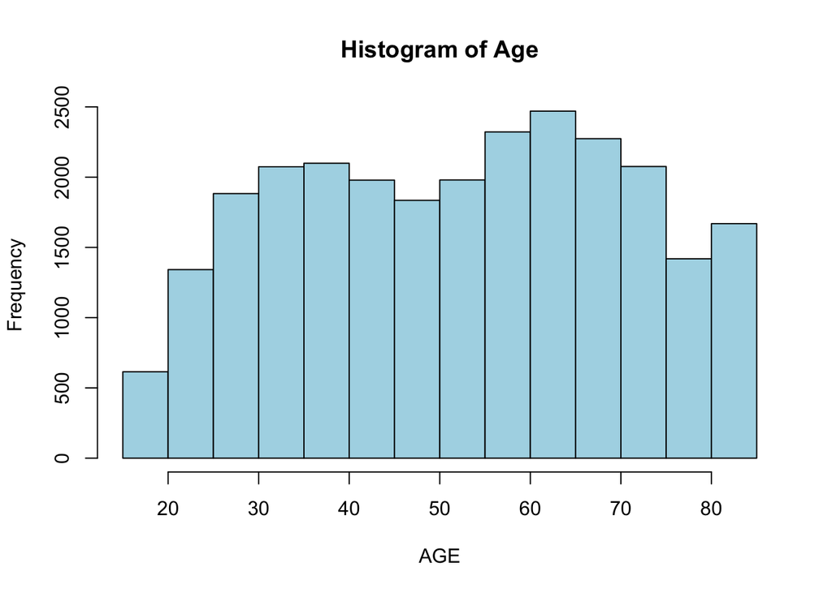

In contrast, categorical variables such as education level, life satisfaction, and health status showed variation in frequency across categories.

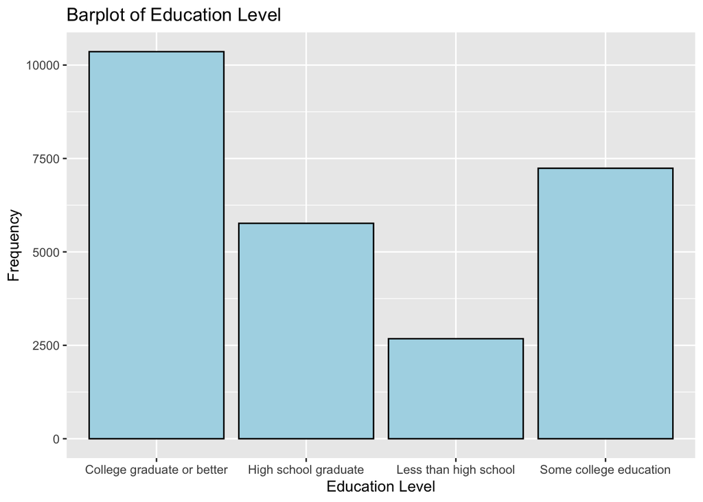

The bar chart shows that the distribution between education levels varies across categories with college graduates having the most frequency.

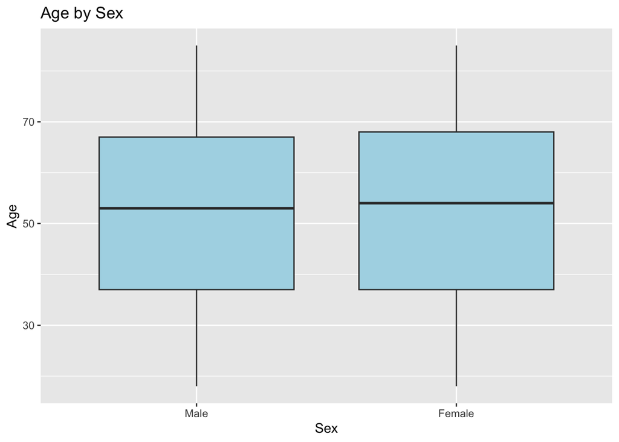